# Longitudinal and Survival Analysis of a Simulated Clinical Study

Tanvir Ahmed

# 1 Introduction

This project was my final assignment for a university course in *Longitudinal and Survival Data Analysis*. The dataset is simulated; my course instructor provided it.

The study has **240 patients** with a chronic disease. Each patient received either the **standard treatment** (`treatment = 0`) or a **new treatment** (`treatment = 1`).

- A **biomarker** was measured four times: at the start (month 0) and at 3, 6 and 12 months.
- Patients were then followed for up to seven years to see whether they **died**.

I answer two questions:

1. **Does the biomarker change over time, and does the change differ between the two treatments?**
2. **Do patients on the new treatment live longer?**

```r
library(tidyverse)  # reading, reshaping and plotting data
library(lme4)       # linear mixed model
library(lmerTest)   # p-values for the mixed model
library(survival)   # Kaplan-Meier, log-rank test and Cox model
```

# 2 Data

```r
data_wide <- read.table("data/extra_data.txt", header = TRUE)
head(data_wide)
```

```
##   id treatment age sex    bio_0    bio_3    bio_6   bio_12    follow death
## 1  1         1  77   1 70.30169 55.00377 58.34121 43.48814 2.6428327     0
## 2  2         1  79   0 64.88370 60.05012 61.05127 51.59900 2.4254194     0
## 3  3         0  64   0 68.23759 59.34814 58.49068 55.68577 0.1173484     1
## 4  4         0  69   1 64.75539 60.23102 55.73027 48.05589 0.1770661     0
## 5  5         1  48   0 69.14116 58.95023 60.16525 47.09809 1.3736019     0
## 6  6         0  66   1 66.70194 70.82596 62.91949 62.41627 1.8252148     0
```

| Variable | Meaning |
| --- | --- |
| `id` | patient number |
| `treatment` | 0 = standard, 1 = new |
| `age` | age in years |
| `sex` | 0 = female, 1 = male |
| `bio_0`, `bio_3`, `bio_6`, `bio_12` | biomarker at month 0, 3, 6 and 12 |
| `follow` | follow-up time in years |
| `death` | 1 = died, 0 = still alive at the end of follow-up (censored) |

The data have **one row per patient**. For the longitudinal model I need **one row per measurement**, so I reshape the data from wide to long format.

```r
data_long <- data_wide |>
  pivot_longer(cols = starts_with("bio_"),
               names_to = "visit", values_to = "biomarker") |>
  mutate(month = as.numeric(sub("bio_", "", visit)),
         group = factor(treatment, levels = c(0, 1), labels = c("Standard", "New")))

head(data_long)
```

```
## # A tibble: 6 × 10
##      id treatment   age   sex follow death visit  biomarker month group
##   <int>     <int> <int> <int>  <dbl> <int> <chr>      <dbl> <dbl> <fct>
## 1     1         1    77     1   2.64     0 bio_0       70.3     0 New
## 2     1         1    77     1   2.64     0 bio_3       55.0     3 New
## 3     1         1    77     1   2.64     0 bio_6       58.3     6 New
## 4     1         1    77     1   2.64     0 bio_12      43.5    12 New
## 5     2         1    79     0   2.43     0 bio_0       64.9     0 New
## 6     2         1    79     0   2.43     0 bio_3       60.1     3 New
```

```r
nrow(data_long)   # 240 patients x 4 visits = 960 rows
```

```
## [1] 960
```

# 3 Part 1: How does the biomarker change over time?

## 3.1 Plot

Each thin line is one patient. The thick lines are the average of each group.

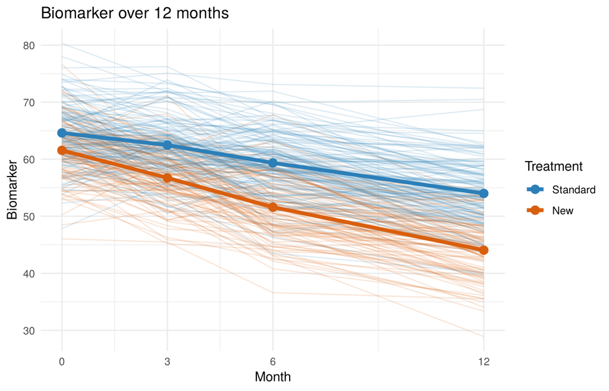

```r
group_means <- data_long |>
  group_by(group, month) |>
  summarise(biomarker = mean(biomarker))

ggplot(data_long, aes(x = month, y = biomarker, colour = group)) +
  geom_line(aes(group = id), alpha = 0.15) +
  geom_line(data = group_means, linewidth = 1.5) +
  geom_point(data = group_means, size = 3) +
  scale_x_continuous(breaks = c(0, 3, 6, 12)) +
  scale_colour_manual(values = c("Standard" = "#2C7FB8", "New" = "#D95F0E")) +
  labs(x = "Month", y = "Biomarker", colour = "Treatment",
       title = "Biomarker over 12 months") +
  theme_minimal()
```

```r
group_means |>
  pivot_wider(names_from = month, values_from = biomarker, names_prefix = "Month ") |>
  knitr::kable(digits = 1)
```

| group | Month 0 | Month 3 | Month 6 | Month 12 |
| --- | --- | --- | --- | --- |
| Standard | 64.6 | 62.5 | 59.4 | 54.0 |
| New | 61.6 | 56.7 | 51.6 | 44.1 |

The biomarker goes down in both groups, and it goes down faster in the new-treatment group. The plot also shows that some patients are always high and others always low, so measurements from the same patient are related.

## 3.2 Linear mixed model

A normal regression assumes every row is independent. Here each patient has four measurements, so they are not independent. A **linear mixed model with a random intercept** handles this by giving each patient their own starting level.

The model is:

> biomarker = time + treatment + time × treatment + (a random starting level for each patient)

The **time × treatment** term tests whether the biomarker changes at a different speed in the two groups.

```r
model <- lmer(biomarker ~ month * treatment + (1 | id), data = data_long)
summary(model)
```

```
## Linear mixed model fit by REML. t-tests use Satterthwaite's method [
## lmerModLmerTest]
## Formula: biomarker ~ month * treatment + (1 | id)
##    Data: data_long
##
## REML criterion at convergence: 5576.4
##
## Scaled residuals:
##      Min       1Q   Median       3Q      Max
## -2.87253 -0.59480 -0.00796  0.59056  2.87380
##
## Random effects:
##  Groups   Name        Variance Std.Dev.
##  id       (Intercept) 17.08    4.133
##  Residual             12.07    3.475
## Number of obs: 960, groups:  id, 240
##
## Fixed effects:
##                  Estimate Std. Error        df t value Pr(>|t|)
## (Intercept)      64.82788    0.42609 343.55466 152.147  < 2e-16 ***
## month            -0.89848    0.03383 718.00000 -26.562  < 2e-16 ***
## treatment        -3.69341    0.64114 343.55466  -5.761 1.86e-08 ***
## month:treatment  -0.55811    0.05090 718.00000 -10.965  < 2e-16 ***
## ---
## Signif. codes:  0 '***' 0.001 '**' 0.01 '*' 0.05 '.' 0.1 ' ' 1
##
## Correlation of Fixed Effects:
##             (Intr) month  trtmnt
## month       -0.417
## treatment   -0.665  0.277
## mnth:trtmnt  0.277 -0.665 -0.417
```

```r
confint(model, parm = "beta_", method = "Wald")
```

```
##                      2.5 %     97.5 %
## (Intercept)     63.9927582 65.6629937
## month           -0.9647815 -0.8321854
## treatment       -4.9500154 -2.4367960
## month:treatment -0.6578665 -0.4583477
```

**What the results mean**

- **`month` (about −0.90):** with the standard treatment, the biomarker goes down by about 0.9 units every month.
- **`month:treatment` (about −0.56, p < 0.001):** with the new treatment, it goes down about 0.56 units *faster* per month, so about 1.46 units per month in total. After 12 months that is roughly 6.7 units more decrease than with the standard treatment.
- **`treatment` (about −3.7):** the new-treatment group already started about 3.7 units lower at month 0. This is a difference between the groups at the start, not an effect of the treatment.
- **Random effects:** the variance between patients (`id`) is larger than the leftover variance (`Residual`). Most of the variation comes from patients being different from each other, which is why a mixed model is needed.

# 4 Part 2: Do patients on the new treatment live longer?

## 4.1 Kaplan–Meier curves

The Kaplan–Meier method estimates the probability of still being alive at each point in time. It also handles patients who were still alive at the end of follow-up (censored).

```r
km <- survfit(Surv(follow, death) ~ treatment, data = data_wide)
km
```

```
## Call: survfit(formula = Surv(follow, death) ~ treatment, data = data_wide)
##
##               n events median 0.95LCL 0.95UCL
## treatment=0 134     60   3.46    2.93      NA
## treatment=1 106     31     NA    4.55      NA
```

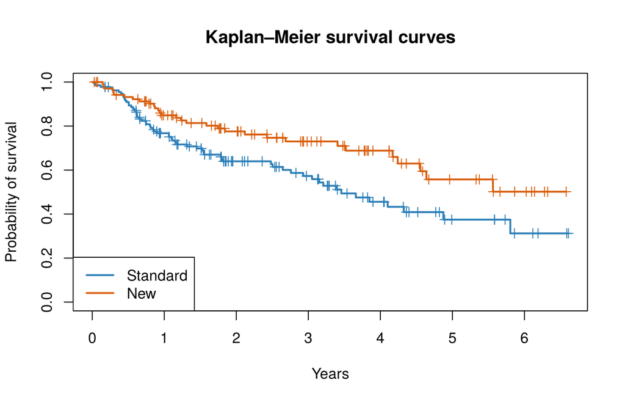

```r
plot(km, col = c("#2C7FB8", "#D95F0E"), lwd = 2, mark.time = TRUE,
     xlab = "Years", ylab = "Probability of survival",
     main = "Kaplan–Meier survival curves")
legend("bottomleft", legend = c("Standard", "New"),
       col = c("#2C7FB8", "#D95F0E"), lwd = 2)
```

```r
summary(km, times = 3)
```

```
## Call: survfit(formula = Surv(follow, death) ~ treatment, data = data_wide)
##
##                 treatment=0
##         time       n.risk      n.event     survival      std.err lower 95% CI
##       3.0000      40.0000      49.0000       0.5730       0.0486       0.4852
## upper 95% CI
##       0.6767
##
##                 treatment=1
##         time       n.risk      n.event     survival      std.err lower 95% CI
##       3.0000      39.0000      24.0000       0.7301       0.0484       0.6411
## upper 95% CI
##       0.8314
```

The new-treatment curve stays above the standard curve during the whole follow-up. After 3 years about **73%** of the new-treatment patients are still alive, compared with about **57%** of the standard-treatment patients.

## 4.2 Log-rank test

The log-rank test checks whether the two survival curves are statistically different.

```r
survdiff(Surv(follow, death) ~ treatment, data = data_wide)
```

```
## Call:
## survdiff(formula = Surv(follow, death) ~ treatment, data = data_wide)
##
##               N Observed Expected (O-E)^2/E (O-E)^2/V
## treatment=0 134       60     47.6      3.23       6.8
## treatment=1 106       31     43.4      3.54       6.8
##
##  Chisq= 6.8  on 1 degrees of freedom, p= 0.009
```

The p-value is **0.009**, which is below 0.05. The survival curves of the two groups are significantly different.

## 4.3 Cox proportional hazards model

The log-rank test does not adjust for other variables. The **Cox model** estimates the effect of treatment while taking **age** and **sex** into account. The result is a **hazard ratio (HR)**:

- HR < 1: lower risk of death
- HR = 1: no difference
- HR > 1: higher risk of death

```r
cox <- coxph(Surv(follow, death) ~ treatment + age + sex, data = data_wide)
summary(cox)
```

```
## Call:
## coxph(formula = Surv(follow, death) ~ treatment + age + sex,
##     data = data_wide)
##
##   n= 240, number of events= 91
##
##               coef exp(coef) se(coef)      z Pr(>|z|)
## treatment -0.57768   0.56120  0.22345 -2.585  0.00973 **
## age        0.03195   1.03246  0.01530  2.088  0.03678 *
## sex        0.12285   1.13072  0.21203  0.579  0.56231
## ---
## Signif. codes:  0 '***' 0.001 '**' 0.01 '*' 0.05 '.' 0.1 ' ' 1
##
##           exp(coef) exp(-coef) lower .95 upper .95
## treatment    0.5612     1.7819    0.3622    0.8696
## age          1.0325     0.9686    1.0020    1.0639
## sex          1.1307     0.8844    0.7462    1.7133
##
## Concordance= 0.617  (se = 0.029 )
## Likelihood ratio test= 11.93  on 3 df,   p=0.008
## Wald test            = 11.3  on 3 df,   p=0.01
## Score (logrank) test = 11.47  on 3 df,   p=0.009
```

**What the results mean**

- **Treatment: HR = 0.56 (95% CI 0.36 to 0.87, p = 0.01).** Patients on the new treatment have about **44% lower risk of death** than patients on the standard treatment of the same age and sex.
- **Age: HR = 1.03.** Each extra year of age increases the risk of death by about 3%.
- **Sex: HR = 1.13, p = 0.6.** There is no clear difference between men and women.

### 4.3.1 Checking the proportional hazards assumption

The Cox model assumes that the hazard ratio stays the same over time. The `cox.zph()` function tests this. A p-value **above 0.05** means the assumption is OK.

```r
cox.zph(cox)
```

```
##            chisq df    p
## treatment 0.0719  1 0.79
## age       0.8605  1 0.35
## sex       0.7530  1 0.39
## GLOBAL    1.5502  3 0.67
```

All p-values are above 0.05, so the assumption holds.

# 5 Conclusions

1. **Biomarker:** the biomarker decreases over time in both groups, and it decreases faster with the new treatment (about 1.46 vs 0.90 units per month).
2. **Survival:** patients on the new treatment live longer. The Kaplan–Meier curves and the log-rank test (p = 0.009) show a clear difference.
3. **Cox model:** after adjusting for age and sex, the new treatment lowers the risk of death by about 44% (HR 0.56).

**Limitation:** the data are simulated, so the results only show how these methods work. They say nothing about a real treatment.